# MRIP Recreational Data Exploration

# Marine Recreational Information Program (MRIP)

> The data collected through MRIP surveys is processed to generate recreational catch and effort estimates. These estimates combine catch rate (average number of fish caught per trip) and effort (total number of fishing trips) to produce a picture of total recreational fishing activity. APAIS data is also used to apportion effort between areas (inland, ocean near-shore, ocean beyond 3 miles) and account for out-of-state fishing activity. This information is combined to generate total catch estimates.

> Fisheries managers and scientists use this information to assess fish stock health and develop regulations that balance resource access with conservation efforts.

Put simply, [MRIP data](https://asmfc.org/programs/management/recreational-data-collection) is used to estimate some proxy for total recreational catch using some average number of fish caught per trip and an estimated number of angler trips.

## MRIP Program Record Details

The Marine Recreational Information Program MRIP program was officially implemented in 2008, when NOAA Fisheries adopted its first Implementation Plna.

There was a predacessor program: the Marine Recreational Fisheries Statistics Surveu (MRFSS), which had been operating since the 1970’s.

MRIP did not roll out uniformly across states/regions, with some implementing parts of the framework at different points in time.

All this together means that there should be some caution when making decisions based on the data in-hand.

### MRIP Data Acquisition

Data was obtained directly from the ASMFC using the [ACCSP Data Warehouse](https://www.accsp.org/what-we-do/data-warehouse/). This online tool allows for direct querying and downloading of subsets of MRIP datasets for catch and effort which are available publicly.

### Loading the downloaded data

Data was stored locally to get things going, and is stored in `.csv` files.

### Data Dictionary / “Schema”

On the portal there is a separate tab section for “warehouse codes”. Here I was able to find a data dictionary for column name descriptions, as well as tables detailing areas fished codes, and other details that might appear in the datasets.

Here is a table with the column descriptions for the two tables we downloaded

Data Dictionary

| Table Name | Column Name | Comments |
| --- | --- | --- |
| CATCH ESTIMATES | B2 PSE | Percent standard error expresses the standard error of an estimate as a percentage of the estimate and is a measure of precision. Large PSEs indicate high variability around estimates and therefore lo… |
| CATCH ESTIMATES | CATCH NUMBERS (A + B1 + B2) | Type A catch are fish brought back to the dock in a form that can be identified by trained interviewers. Type B1 catch are fish that are used for bait, released dead, or filleted -- i.e. they are kill… |
| CATCH ESTIMATES | COMMON NAME | Common name of fish |
| CATCH ESTIMATES | DIST FROM SHORE | Ocean zones. INLAND means inshore saltwater and brackish water bodies such as bays, estuaries, sounds, etc. It does not include inland freshwater areas. STATE TERRITORIAL SEA is a zone extending three… |
| CATCH ESTIMATES | HARVEST (A + B1) | Type A catch are fish brought back to the dock in a form that can be identified by trained interviewers. |
| CATCH ESTIMATES | HARVEST PSE | Percent standard error expresses the standard error of an estimate as a percentage of the estimate and is a measure of precision. Large PSEs indicate high variability around estimates and therefore lo… |
| CATCH ESTIMATES | MODES | Fishing modes (SHORE, PRIVATE/RENTAL BOATS, CHARTER BOAT, HEAD BOAT. North Carolina is the only state to break SHORE mode into BEACH/BANK and MAN MADE.) |
| CATCH ESTIMATES | NUMBERS (A) | Type A catch are fish brought back to the dock in a form that can be identified by trained interviewers. |
| CATCH ESTIMATES | NUMBERS PSE | Percent standard error expresses the standard error of an estimate as a percentage of the estimate and is a measure of precision. Large PSEs indicate high variability around estimates and therefore lo… |
| CATCH ESTIMATES | NUMBERS RELEASED ALIVE (B2) | Type B2 catch is fish that are released alive - again, identification is by individual anglers. |
| CATCH ESTIMATES | REGION | Ocean regions (North Atlantic, Mid-Atlantic, South Atlantic, Gulf of Mexico). Useful to group states and divide Florida East and West coast estimates. |
| CATCH ESTIMATES | SCI NAME | Latin name of fish |
| CATCH ESTIMATES | STATE | State in which fishing interview occurred |
| CATCH ESTIMATES | TOTAL CATCH PSE | Percent standard error expresses the standard error of an estimate as a percentage of the estimate and is a measure of precision. Large PSEs indicate high variability around estimates and therefore lo… |
| CATCH ESTIMATES | WAVE | Two-month reference period (e.g. Wave 1=January/February) |
| CATCH ESTIMATES | WEIGHT (LB) OF HARVEST (A + B1) | Type A catch are fish brought back to the dock in a form that can be identified by trained interviewers. Type B1 catch are fish that are used for bait, released dead, or filleted -- i.e. they are kill… |
| CATCH ESTIMATES | WEIGHT HARVEST PSE | Percent standard error expresses the standard error of an estimate as a percentage of the estimate and is a measure of precision. Large PSEs indicate high variability around estimates and therefore lo… |
| CATCH ESTIMATES | YEAR | Calendar year of fishing activity |
| EFFORT ESTIMATES | DIST FROM SHORE | Ocean zones. INLAND means inshore saltwater and brackish water bodies such as bays, estuaries, sounds, etc. It does not include inland freshwater areas. STATE TERRITORIAL SEA is a zone extending three… |
| EFFORT ESTIMATES | MODE | Fishing modes (SHORE, PRIVATE/RENTAL BOATS, CHARTER BOAT, HEAD BOAT. North Carolina is the only state to break SHORE mode into BEACH/BANK and MAN MADE.) |
| EFFORT ESTIMATES | MRIP TRIPS IN MODE AREA | Number of recreational fishing angler trips. |
| EFFORT ESTIMATES | MRIP TRIPS PSE | Percent standard error expresses the standard error of an estimate as a percentage of the estimate and is a measure of precision. Large PSEs indicate high variability around estimates and therefore lo… |
| EFFORT ESTIMATES | REGION | Ocean regions (North Atlantic, Mid-Atlantic, South Atlantic, Gulf of Mexico). Useful to group states and divide Florida East and West coast estimates. |
| EFFORT ESTIMATES | STATE | State in which fishing interview occurred |
| EFFORT ESTIMATES | WAVE | Two-month reference period (e.g. Wave 1=January/February) |
| EFFORT ESTIMATES | YEAR | Calendar year of fishing activity |

A key piece of information in the data dictionary that affects a number of columns is the fish `type` that was reported:

- A: Type A catch are fish brought back to the dock in a form that can be identified by trained interviewers.
- B1 : Type B1 catch are fish that are used for bait, released dead, or filleted – i.e. they are killed but identification is by individual anglers.
- B2: Type B2 catch is fish that are released alive - again, identification is by individual anglers.

The catch summaries appear to come in two groups:

1. Fish that are caught and kept (A + B1)
2. All Fish caught

Another important bit of information is the Ocean Zones used. There are five zones detailed in the data dictionary, some of which are nested: - Inland: inshore saltwater and brackish water bodies such as bays, estuaries, sounds, etc. It does not include inland freshwater areas.  
- State Territorial Sea: zone extending three nautical miles from shore for all states except the Gulf coast of Florida where the seaward boundary is 3 marine leagues (approximately 10 statute miles). The state territorial seas do not include inland areas.  
- State Waters: the combination of inland and state territorial seas. - Federal Exclusive Economic Zone (EEZ): contiguous to the State Territorial Seas of all the United States and its possessions and extends seaward 200 nautical miles measured from the baseline from which the Territorial Sea is measured. - Ocean: Combination of the State Territorial Sea and the EEZ

With these zones “Ocean” is the most inclusive, incorporating all except the “Inland” waters. State waters are another general category, lumping inland and state territorial sea.

This is what they look like on a map:

[figure not shown]

## Making a Map of Different Programs

It has come up across projects to try and map the different coverages of these programs somehow to give a sense of the imte/space overlaps of the different means available to survey populations.

# Digging in on Key Species

Everything below is built to provide summary details on one specific species:

### Total Recreational Catch Area Plots

Shaded areas display change in total recrteational catch by state, and organized by council region.

[figure not shown]

### Presence/Absence Heatmap

A heatmap provides a quick look at the years when species are present or absent from the MRIP recreational data, providing a window into whether a species is persistently present in a state’s recreational catch.

[figure not shown]

### Recreational Catch Bubblemap

Recreational data categorizes the reporting by whether it was caught and released, and the level of identity verification. You can end up with different numbers if you only look at catch that was brought back to the docks.

[figure not shown]

# MRIP Summary Tables

gt tables mights be a good means to provide a summary of the MRIP information in one spot.

The following chunk of code links out to local image files for species illustrations downloaded from either MAFMC or ASMFC.

The data needs to be tidied up for the table. First I get all combinations of year and state so I can preserve any absences/breaks in the MRIP reporting. I also add a minimum records cutoff that will toggle whether or not a trend is computed (5 or fewer is not computed). I also am only reporting on the most recent 15 years of data here.

### Concise MRIP Catch Table

The more concise version of the table/scorecard has the following information:

- Presence/absence over the last 15 years
- The fraction of recreational harvest from each state (timeseries)
- Trend results from that harvest proportion

Species of Interest: Black Sea Bass

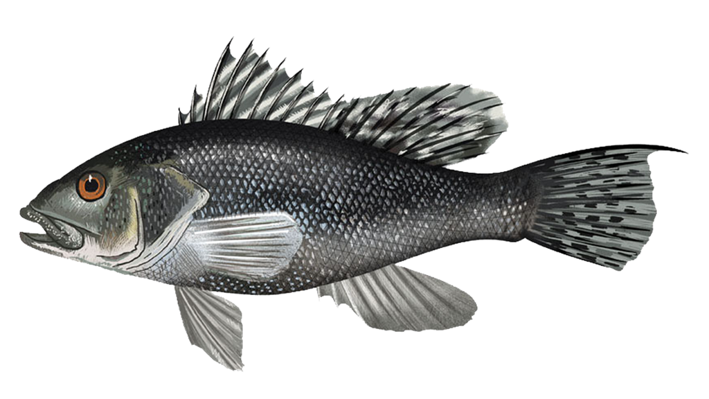

MRIP Recreational Harvest Trends Over the Last 15 Years

State

Presence / Absence

Proportion of Recreational Catch

Harvest %

Trend

North Atlantic

Maine

[figure not shown]

Limited Data

New Hampshire

[figure not shown]

Stable

Massachusetts

Decreasing

Rhode Island

Stable

Connecticut

Stable

Mid Atlantic

New York

Stable

New Jersey

Increasing

Delaware

Stable

Maryland

Stable

Virginia

Increasing

South Atlantic

North Carolina

Stable

South Carolina

[figure not shown]

Stable

Georgia

Stable

Florida

Stable

### MRIP Table Full

It may be helpful to also report actual abundance numbers and whether they are increasing/decreasing. This feels like a lot of information though…

Species of Interest: Black Sea Bass

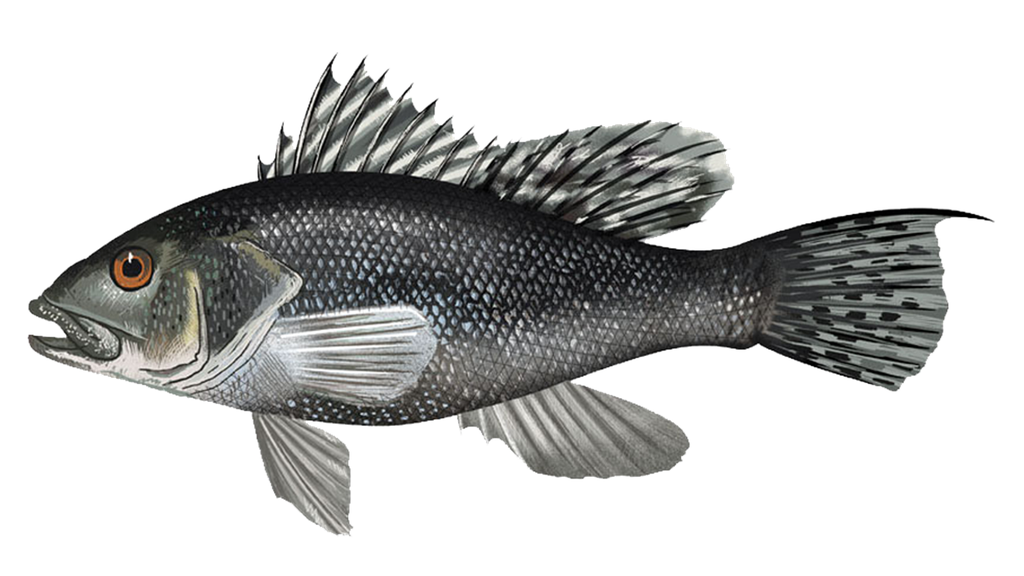

MRIP Recreational Harvest Trends of the Last 15 Years

State

Presence/Absence

Total Catch Trends:

Catch Proportion Trends:

Total Recreational Harvest

Catch Trend

% of Recreational Harvest

Proportion Trend

North Atlantic

Maine

[figure not shown]

Limited Data

[figure not shown]

Limited Data

New Hampshire

[figure not shown]

Stable

[figure not shown]

Stable

Massachusetts

Decreasing

Decreasing

Rhode Island

Stable

Stable

Connecticut

Stable

Stable

Mid Atlantic

New York

Stable

Stable

New Jersey

Stable

Increasing

Delaware

Stable

Stable

Maryland

Stable

Stable

Virginia

Increasing

Increasing

South Atlantic

North Carolina

Stable

Stable

South Carolina

Decreasing

[figure not shown]

Stable

Georgia

Decreasing

Stable

Florida

Stable

Stable

## Processing Tables for Shortlist Species

I change my mind and think we should export the full tables. The steps needed to save the table are: * subset the catch for that species * expand on state * region * year to capture gaps * estimate trends * determine messaging/takeaways * create tables

This fist chunk pulls the catch for each species:

This next one does the trends and messaging:

Here the tables are made:

Species of Interest: Atlantic Mackerel

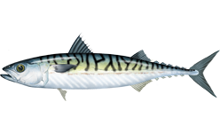

MRIP Recreational Harvest Trends of the Last 15 Years

State

Presence/Absence

Total Catch Trends:

Catch Proportion Trends:

Total Recreational Harvest

Catch Trend

% of Recreational Harvest

Proportion Trend

North Atlantic

Maine

Stable

Increasing

New Hampshire

Decreasing

Decreasing

Massachusetts

Decreasing

Stable

Rhode Island

Increasing

[figure not shown]

Increasing

Connecticut

Stable

[figure not shown]

Stable

Mid Atlantic

New York

Stable

[figure not shown]

Stable

New Jersey

Stable

[figure not shown]

Delaware

[figure not shown]

Limited Data

[figure not shown]

Limited Data

Maryland

[figure not shown]

Limited Data

[figure not shown]

Limited Data

Virginia

[figure not shown]

Limited Data

[figure not shown]

Limited Data

South Atlantic

North Carolina

Decreasing

[figure not shown]

South Carolina

[figure not shown]

Limited Data

[figure not shown]

Limited Data

Georgia

[figure not shown]

Limited Data

[figure not shown]

Limited Data

Florida

[figure not shown]

Limited Data

[figure not shown]

Limited Data

Now save those out somewhere that others can review them:

### Tables with Map

I spent too much time trying to incorporate a regional map into the gt table. The plotting by region works, but getting it to appear once per group is not…

### Adding in Effort

Effort is not summarized in terms of inshore/offshore, and insteadh is summarized at the state level.

[figure not shown]